# Background

Texans are currently suffering a winter storm of deadly proportions. Thus far, [37 people](https://www.nbcnews.com/news/us-news/texas-contending-water-nightmare-top-power-crisis-n1258208) have died from weather-related fatalities, [4 million](https://www.nbcnews.com/news/weather/knocked-out-texas-millions-face-record-lows-without-power-new-n1257964) people have lost power, [12 million](https://www.nbcnews.com/news/us-news/texas-contending-water-nightmare-top-power-crisis-n1258208) people have had their water disrupted, and [300 people](https://www.houstonchronicle.com/news/houston-texas/health/article/Memorial-Hermann-sees-60-carbon-monoxide-15954216.php) have been hospitalized for carbon monoxide poisoning. This climate crisis and its deadly impacts have been largely driven by a failure of Texas’s centralized power grid, a willful neglect of new investment in energy infrastructure, denials of the science of climate change, and the exacerbation of existing structural inequities for BIPOC (Black, Indigenous, People of Color) individuals and families of low income.

**We are excited to announce an informal Urban-wide mutual aid donation campaign for Texans affected by the winter storm of 2021.** The campaign will be an optional, virtual, and anonymous collection open to all Urban staff from various centers and offices to donate what they can from their own personal funds. We will be recording and tracking all of our donations on this website, so check back for updates.

We have chosen to direct all proceeds raised from this campaign to mutual aid groups in Texas, because they have been one of the most flexible and fastest ways for [immediate needs](https://itsgoingdown.org/autonomous-mutual-aid-groups-mobilize-in-texas-as-death-toll-rises) to be met during the winter storm. For example, when there was no coordinated plan to assist house-less people prepare for the dropping temperatures, [mutual aid groups were the first](https://www.kxan.com/news/local/austin/helping-the-homeless-austin-volunteers-pay-for-hotel-rooms-deliver-food) to pay for their hotel rooms, drive to shelters, and pay for food.

This campaign will begin on Friday, February 19th, and close on February 26th. [You can read a more about the background of the crisis, the conditions that led to it, and a bit of background of mutual aid organizations here](https://docs.google.com/document/d/1omQhlCRj8k25Tu9EHne2Dez7XpStEq_3uxwnmZTkwUE/edit?usp=sharing).

# Fundraising Totals

#### Last updated - Mar 15, 10:54 AM

### **Our goal is $20,000. So far we have:**

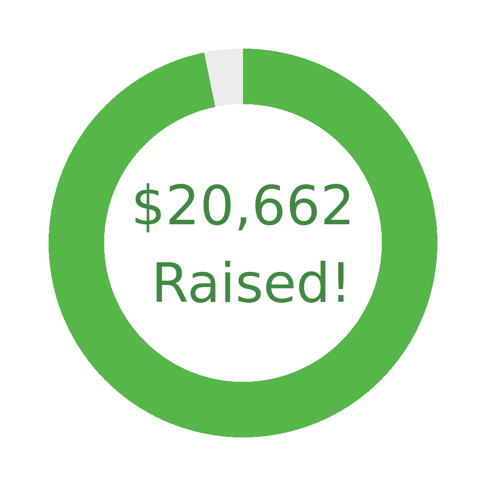

### **Among centers, MET is leading!**

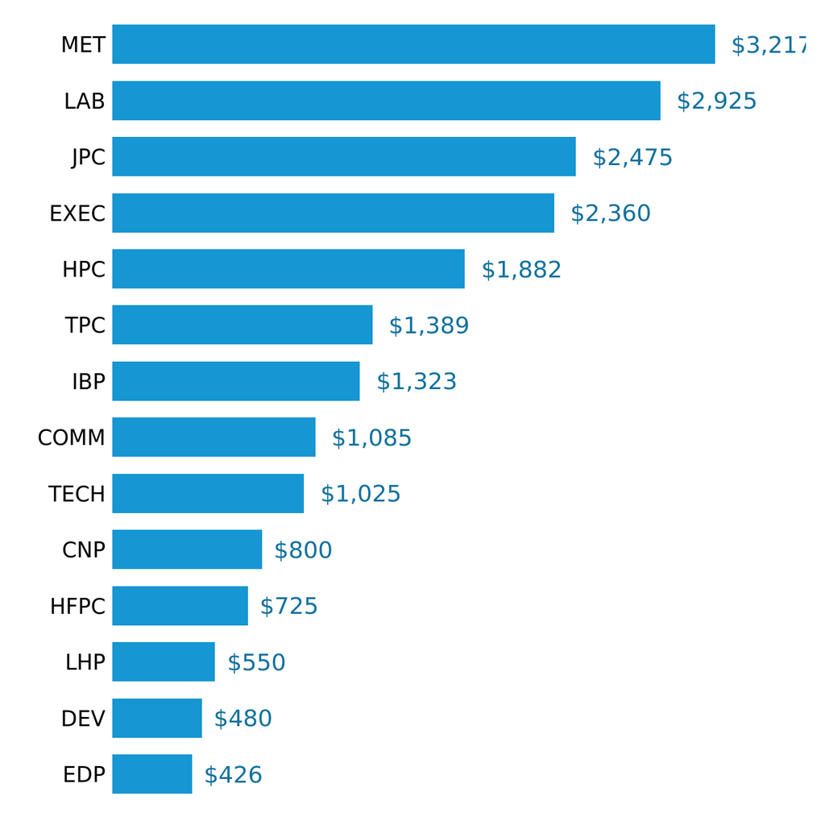

### **In terms of dollars per person, EXEC is leading!**

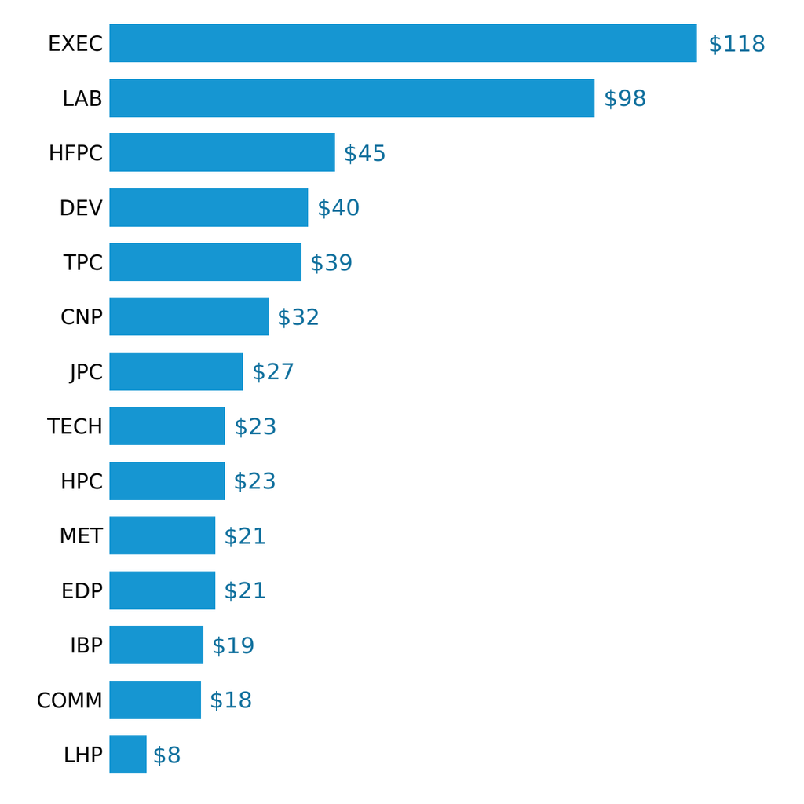

# Where we distributed the money

Together, Urban was able to raise $20,662, including Venmo and paypal donations, and receipts from folks who donated directly. The total of $14,846.90 (all of the donations collected via Venmo and Paypal) were distributed to 6 organizations from March 1st to 6th.The 6 organizations received were chosen because they had donations open, have a documented history of effective mutual aid distribution, have campaigns related to winter storm relief, are focused on supporting BIPOC individuals, and have a policy angle (focus on housing, policing, or racial inequity).

- [Corpus Christi Mutual Aid](https://www.facebook.com/CCMutualAid/) (Corpus Christi)
- [Feed the People Dallas](https://feedthepeopledallas.com/) (Dallas)
- [Say Her Name Texas](https://www.sayhernametexas.org/) (Houston)
- [Black Futures Collective](https://twitter.com/BlackFuturesSA) (San Antonio)
- [Texas Jail Project](https://www.texasjailproject.org/about-us/) (Texas-wde)
- [MS Rising Coalition](https://www.msrising.com/) (Mississippi-wide)

So far, these organizations have provided water, shelter, immediate relief, and support to people in both Texas and Mississippi. One group shared that our funds arrived just in time for them to do life-affirming work: “First off, thank you. We really appreciate it, and we’re so shook right now, thank you for supporting our work.”

# How to donate?

You can donate in two ways:

1. You can send donations via venmo to your Center’s point person (See table below)/ Make sure to include “Mutual aid –[Your Center/Office]” in the subject line of your donation to be included in your center’s count.
2. You can also directly donate to any organization supporting people who are in need during the climate crisis and send the receipt to your Center’s point person (See table below). Make sure to include “Mutual aid – [Your Center/Office]” in the email subject line, so your contribution can be included in your center’s count! Extra fun if your emailed receipts include a description of the organization or person conducting the support.

If your center/office is not listed, please consider representing your center/office. Reach out to jjagannath@urban.org and storresrod@urban.org if you can volunteer, and we will get you plugged in!

### Center Point People

| Center | Names | Venmo | Paypal | Email |
| --- | --- | --- | --- | --- |
| CNP | Nora, Claire | Nora_Hakizimana | paypal.me/NoraHakizimana | nhakizimana@urban.org |
| COMM | Katie Robertson | Katie-Robertson-8 | paypal.me/KatieRobertson24 | KRobertson@urban.org |
| DEV | Emily Munguia | Emily-Munguia-3 |  | emunguia@urban.org |
| EDP | Mitch Rybak, Macy Ranier | mitchell-rybak |  | Mrainer@urban.org or mrybak@urban.org |
| EXEC | Matt Rogers | mrogers716 | mrogers716@gmail.com | mrogers@urban.org |
| HFPC | Cait Young, JP Walsh | Cait_Young |  | cyoung@urban.org |
| HPC | Clara Alvarez | Clara-AlvarezCaraveo |  | calvarezcaraveo@urban.org |
| IBP | Danielle Kwon | DanielleKwon | paypal.me/daniellekwon95 | dkwon@urban.org |
| JPC | Jahnavi Jagannath, Lauren Farrell, Melanie Langness | Jahnavi-Jagannath | paypal.me/langness316 | jjagannath@urban.org |
| LAB | Megan Randall | Megan-Randall-1 | MRandall149 | mrandall@urban.org |
| LHP | Kate Thomas | katethomas81 | kateathom@gmail.com | kthomas@urban.org |
| MET | Sonia Torres, Abby Williams, Peace Guam | Peace-Gwam | paypal.me/peacegwam | pgwam@urban.org |
| TECH | Ajjit Narayanan | Ajjit-Narayanan |  | anarayanan@urban.org |
| TPC | Nikhita Airi | Nikhita-Airi | paypal.me/nikhitaairi | nairi@urban.org |

# More ways to help

The Texas Jail Project is asking people to donate funds to the commissary accounts of folks trapped in Texas jails without heat or water and with diminishing supplies of food. Your donations will be reimbursed later by the Texas Jail Project, if you like, but they really need people to log in and make the donations because there are limits on how many donations a single person can make each day to accounts for incarcerated people.

I am forwarding a note from our friends at the Texas Jail Project, who are in need of some critical support getting money into folks’ commissary accounts. As you’re all probably aware, Texas is freezing over and people have been without power, food, and heat for days now. As we know in these kinds of crises, conditions inside jails and prisons are that much more unlivable. Commissary helps people get edible food, clean water, warmer clothes, and meet other immediate needs. The Texas Connect network system via which funds are sent only allows up to three commissary payments per day per person, so as many hands on deck who can help distribute funds, the better! **TX Jail Project will fully reimburse via PayPal or Venmo once they get through survival mode this week**.

More specific directions in this [spreadsheet](https://docs.google.com/spreadsheets/d/1KMgVY6_MEygcT0OrwibYoocye7dS9oi_XSyrWg4dTXI/edit?usp=sharing), and please forward to any of your friends, family, members, partners etc. who can afford to send some cash without immediate reimbursement at this time.